# R Notebook

Takto vám vyznačím komentáre. Prvý je, ľe váą skript nefunguje - treba explicitne načíta» dáta, nemôľete sa spolieha», ľe si ich niekto múdro načíta vopred, kým si spusttí váą kód. Príkaz získate tak, ľe pouľijete z menu `File/Import dataset/From text (base)`, vyberiete súbor `diet.csv`, zaąkrtnete `Heading : Yes`, dáte OK a potom si príkaz odkopírujete z konzoly do skriptu. Takľe toto ste mali spravi»:

```r
library(tidyverse)

diet <- read.csv("C:\\Users\\Juro\\Desktop\\diet.csv", header=TRUE)
diet <- read.csv(diet.csv, header = TRUE)

head(diet)
```

```r
diet$stratavahy = diet$pre.weight - diet$weight6weeks
#týmto krokom som si vyjadril zmenu hmotnosti počas doby trvania experimentu (6 týľdňov)
```

“robi» ątandardný graf (plot) je z týchto dát bezvýznamné, nie je medzi nimi ľiadna súvislos».”

No to sa mýlite. Ak sa vaąe premenné volajú V1, V2 a podobne, tak sa to môľe zamota». Ale môľeme sa predsa pýta», aký je účinok dieéty, či je pokles váhy významný (tým nemyslím priamo ątatisticky signifikantný, lebo ątatisticky signifikantný môľe by» aj pokles o 10 gramov, ak spravíte dostatočne veµkú ątúdiu, a kvôli takému poklesu nebude nikto podstupova» diétu). A môľeme sa pýta», či je rozdiel medzi ľenami a muľmi, či je pokles váhy relatívny alebo absolútny, či závisí od veku, či je lepąie pozera» sa na diétu cez stratu váhy alebo BMI. Takľe vám dám pár nápadov, a nechám vás s nimi pracova».

Zavedieme BMI, aj keď to je nie celkom zmysluplnýý parameter.

```r
diet %>%
  mutate(
    stratavahy = pre.weight - weight6weeks,
    pre.bmi = pre.weight / (Height/100)**2,
    bmi6weeks = weight6weeks / (Height/100)**2,
    bmi.ratio = (pre.bmi - bmi6weeks)/pre.bmi # to je zároveň aj relatívna strata váhy
  ) -> diet
head(diet)
```

|  | Person | gender | Age | Height | pre.weight | Diet | weight6weeks | stratavahy | pre.bmi | bmi6weeks | bmi.ratio |
| --- | --- | --- | --- | --- | --- | --- | --- | --- | --- | --- | --- |
| 1 | 1 | 0 | 22 | 159 | 58 | 1 | 54.2 | 3.8 | 22.94213 | 21.43903 | 0.06551724 |
| 2 | 2 | 0 | 46 | 192 | 60 | 1 | 54.0 | 6.0 | 16.27604 | 14.64844 | 0.10000000 |
| 3 | 3 | 0 | 55 | 170 | 64 | 1 | 63.3 | 0.7 | 22.14533 | 21.90311 | 0.01093750 |
| 4 | 4 | 0 | 33 | 171 | 64 | 1 | 61.1 | 2.9 | 21.88708 | 20.89532 | 0.04531250 |
| 5 | 5 | 0 | 50 | 170 | 65 | 1 | 62.2 | 2.8 | 22.49135 | 21.52249 | 0.04307692 |
| 6 | 6 | 0 | 50 | 201 | 66 | 1 | 64.0 | 2.0 | 16.33623 | 15.84119 | 0.03030303 |

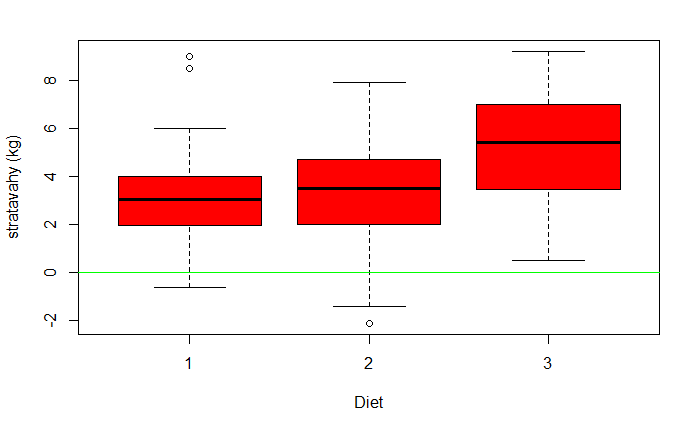

```r
boxplot(stratavahy~Diet,data=diet,col="red",ylab = "stratavahy (kg)", xlab = "Diet")
abline(h=0,col="green")
```

na tomto boxplote môľeme vidie» zmenu váhy v závislosti od typu diéty. Typy diét boli anonymizované, nepoznáme ich priebeh, ale z výsledku moľno jasne usúdi», ľe diéta 3 bola najúčinnejąia. Názov osi V7 predstavuje typ diéty, ale v datasete mi to neąlo zmeni», bez jeho znefunkčnenia.

Nevidím, kde by mohol by» problém, môľete si premennú µahko premenova» ako chcete. Teraz máme pomenovania správne, a zmenil som ich aj vo vaąom kóde, ale keby ste chceli premenova» nejaký stĺpec, robí sa to takto: `diet %>% rename(nove.meno1 = stare.meno1, nove.meno2 = stare.meno2) -> diet`. A osi grafu si môľete pomenova» ako chcete.

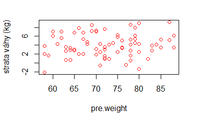

```r
plot(stratavahy~pre.weight,data=diet,col="red",ylab = "strata váhy (kg)", xlab = "pre.weight")
abline(h=55,col="green")
```

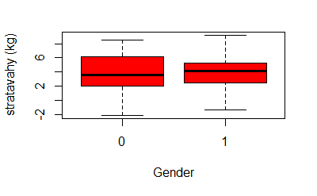

```r
boxplot(stratavahy~gender,data=diet,col="red",ylab = "stratavahy (kg)", xlab = "Gender")
abline(h=55,col="green")
```

tu vidíme celkovú zmenu váhy (nehľadiac na typ diéty) v závislosti od typu vohlavia. Nevieme, ktorý údaj predstavuje aké pohlavie, vieme iba urči», ľe pohlavie 1 je úspeąnejąie. Názov osi V2 predstavujepohlavie.

To máte pravdu, ale to sa dá µahko zisti», od toho sme dátoví detektívi.

Takľe môľeme µahko odkódova», čo sú nuly a čo jednotky, a upravi» si dáta.

tapply(diet$stratavahy, diet$pre.weight,median) #presné vyčíslenie strednej hodnoty zmeny váhy. Dá sa odčíta» z boxplotov (stredová čiara), ale toto je presnejąie. I tak ąe da, ale toto je predsa čitateµnejąie, môľeme si napočíta» aj chyby - keďľe máme mediány, tak mediánové absolútne odchýlky ako analóg ątandardnej odchýlky:

```r
diet %>%
  group_by(gender, Diet) %>%
  summarize(
    med.prew = median(pre.weight),
    mad.prew = mad(pre.weight),
    med.bmi = median(pre.bmi),
    mad.bmi = mad(pre.bmi),
    med.strata = median(stratavahy),
    mad.strata = mad(stratavahy)
  ) -> summary.diet
summary.diet
```

| gender | Diet | med.prew | mad.prew | med.bmi | mad.bmi | med.strata | mad.strata |
| --- | --- | --- | --- | --- | --- | --- | --- |
| 0 | 1 | 68.0 | 5.9304 | 22.71674 | 3.213622 | 2.85 | 1.33434 |
| 0 | 2 | 63.0 | 5.1891 | 22.64813 | 2.688378 | 2.85 | 1.85325 |
| 0 | 3 | 69.0 | 4.4478 | 24.96495 | 2.233365 | 6.80 | 1.18608 |
| 1 | 1 | 80.0 | 8.1543 | 29.11314 | 3.107574 | 3.70 | 1.55673 |
| 1 | 2 | 78.0 | 2.9652 | 21.05263 | 3.133795 | 4.30 | 2.22390 |
| 1 | 3 | 78.5 | 7.4130 | 26.43695 | 2.871929 | 3.80 | 2.07564 |

ale obrázok povie viac ako hromada čísel. Tak si dáta preusporiadame a skúsime poriadne vykresli».

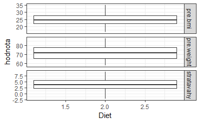

```r
diet %>%
  select(gender, Diet, pre.weight, pre.bmi, stratavahy) %>% # aby sme nemali prive2a stlpcov
  gather(
    key = "parameter", value = "hodnota", c(pre.weight, pre.bmi, stratavahy)
    ) %>%
  ggplot(aes(x = Diet, y = hodnota, colour = gender)) +
  theme_bw() +
  facet_grid(parameter~., scales = "free_y") +
  geom_boxplot()
```

```r
kruskal.test(stratavahy~pre.weight,data=diet)
```

```
    Kruskal-Wallis rank sum test

data:  stratavahy by pre.weight
Kruskal-Wallis chi-squared = 32.126, df = 28, p-value = 0.2694
```

No, len keď si pozriete porovnanie, zistíte, ľe potrebujeme porovna» pohlavie x dietu, a eąte tam máme ako kovariáty vek, vstupnú váhu a vstupné bmi. Takľe môľete skúsi» Kruskala na diétu, ale pre muľov a ľeny osobitne. A hlavne si to treba nakresli» a zváľi», čo sú dobré prediktory. takéto niečo myslím:

```r
diet %>%
  select(gender, Diet, Age, pre.weight, pre.bmi, stratavahy) %>% # aby sme nemali prive2a stlpcov
  gather(
    key = "parameter", value = "hodnota", c(Age, pre.weight, pre.bmi) # parametre budu iba prediktory
    ) %>%
  ggplot(aes(x = hodnota, y = stratavahy, colour = gender)) +
  theme_bw() +
  facet_grid(Diet ~ parameter, scales = "free") +
  geom_point() +
  geom_smooth(method = "lm")
```

[output not shown]

```r
t.test(pre.bmi, y = NULL, alternative = c("two.sided", "less", "greater"),mu = 0, paired = FALSE, var.equal = FALSE, conf.level = 0.95)
```

```
    One Sample t-test

data:  pre.bmi
t = 55.691, df = 75, p-value < 2.2e-16
alternative hypothesis: true mean is not equal to 0
95 percent confidence interval:
 24.15345 25.94551
sample estimates:
mean of x
 25.04948
```